# Codon rate screen with evolution

Alex Lukasiewicz

1/25/2019

An initial screen of codon speeds yielded the following:

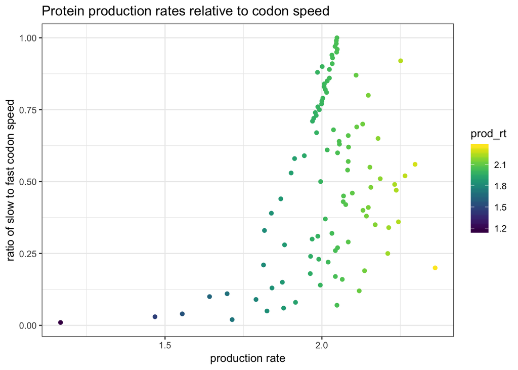

```r
fast_slow <- read.csv("scripts/transcript_stats_011619.csv", header = FALSE)
fast_slow <- as.data.frame(fast_slow[c(1:3)])
colnames(fast_slow) <- as.character(unlist(fast_slow[1,]))
fast_slow <- fast_slow[-1, ]
fast_slow[, 1] <- as.numeric(as.character( fast_slow[, 1] ))
fast_slow[, 2] <- as.numeric(as.character( fast_slow[, 2] ))
fast_slow[, 3] <- as.numeric(as.character( fast_slow[,3]  ))
fast_slow <- as.tibble(fast_slow)
fast_slow <- mutate(fast_slow, ratio_slow_fast = slow_rt/fast_rt)
fast_slow <- arrange(fast_slow, prod_rt)
ratio_plot <- ggplot(fast_slow, aes(x = prod_rt, y= ratio_slow_fast, group = 1)) + geom_point(aes(colour = prod_rt)) + scale_color_viridis() + ylab('ratio of slow to fast codon speed') + xlab('production rate') + theme(legend.position = 'none') +
  ggtitle('Protein production rates relative to codon speed') +
  theme_bw()
plot(ratio_plot)
```

To optimize transcripts at a variety of protein production rates, evolved each rate ratio for 50 generations. plot: final rates, overall stochasticity of rate ratio (measure changes in production rate for each ratio)

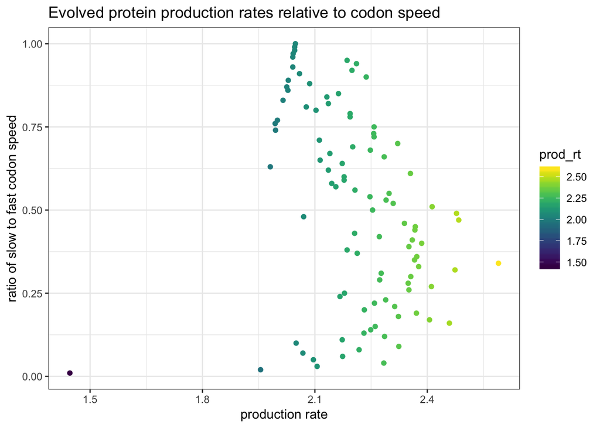

```r
evolved_rate_array <- read.csv("data/codon_optimization_data/final_fitness_all.csv", header = FALSE)
evolved_rate_df <- as.data.frame(evolved_rate_array)
evolved_rate_df[, 1] <- as.numeric(as.character( evolved_rate_df[, 1] ))
evolved_rate_df[, 2] <- as.numeric(as.character( evolved_rate_df[, 2] ))
evolved_rate_df[, 3] <- as.numeric(as.character( evolved_rate_df[,3]  ))
evolved_rate_df <- mutate(evolved_rate_df, ratio_slow_fast = evolved_rate_df$V1/evolved_rate_df$V2)
evolved_rate_df <- arrange(evolved_rate_df, ratio_slow_fast)
ratio_plot <- ggplot(evolved_rate_df, aes(x = V3, y= ratio_slow_fast, group = 1)) + geom_point(aes(colour = V3)) + scale_color_viridis() + ylab('ratio of slow to fast codon speed') + xlab('production rate') + theme(legend.position = 'none') +
  ggtitle('Evolved protein production rates relative to codon speed') +
  labs(color = 'prod_rt') +
  theme_bw()
plot(ratio_plot)
```

```r
save_plot("array_evolved_production_rates.png", ratio_plot, base_aspect_ratio = 1.3)
```

Additionally, this may be possible by plotting the difference between the initial production rate and the final

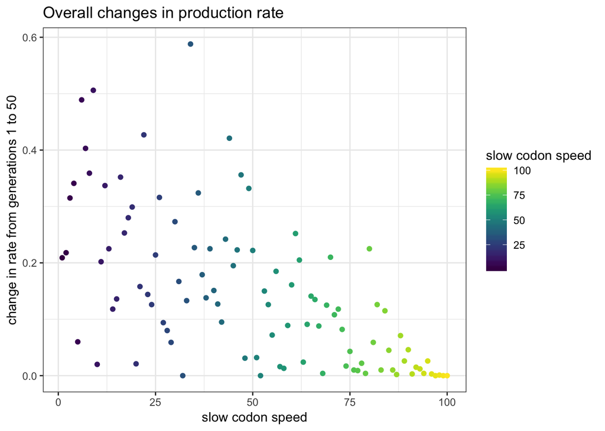

```r
dif <- read.csv('data/codon_optimization_data/change_in_rt.csv',header = TRUE)
dif <- as.data.frame(dif)
dif_plot <- ggplot(dif, aes(x= min.speed, y = change.in.production.rate, group = 1)) + geom_point(aes(color = min.speed)) + scale_color_viridis() + xlab('slow codon speed') + ylab('change in rate from generations 1 to 50') + theme(legend.position = 'none') + ggtitle('Overall changes in production rate') + labs(color = 'slow codon speed') + theme_bw()
plot(dif_plot)
```

```r
#dif_plot <- dif_plot + geom_smooth(method = 'lm', se = FALSE, fullrange = TRUE, color = '#2ca25f')
save_plot("changes_evolved_production_rates.png", dif_plot, base_aspect_ratio = 1.3)
```

## Well, what if we evolve each rate pairing for 500 generations instead??

```r
transcript_stats<- read.csv("data/presentation_datasets/transcript_stats_500_gen.csv", header = FALSE, strip.white = TRUE)
transcript_stats <- as.data.frame(transcript_stats[c(2:8)])
colnames(transcript_stats) <- as.character(unlist(transcript_stats[1,]))
transcript_stats <- transcript_stats[-1, ]
transcript_stats[, 1] <- as.numeric(as.character( transcript_stats[, 1] ))
transcript_stats[, 2] <- as.numeric(as.character( transcript_stats[, 2] ))
transcript_stats[, 3] <- as.numeric(as.character( transcript_stats[, 3] ))
transcript_stats[, 7] <- as.numeric(as.character( transcript_stats[, 7] ))
transcript_stats
```

|  | Generation | Pct_slow | Pct_fast | Mutation_loc | Mutation | Rate | Min Rate |
| --- | --- | --- | --- | --- | --- | --- | --- |
| 2 | 0 | 55.83333 | 44.16667 | 75 | 100 | 1.19 | 1 |
| 3 | 1 | 56.66667 | 43.33333 | 15 | 1 | 1.293 | 1 |
| 4 | 2 | 56.66667 | 43.33333 | 65 | 1 | 1.293 | 1 |
| 5 | 3 | 56.66667 | 43.33333 | 91 | 100 | 1.293 | 1 |
| 6 | 4 | 56.66667 | 43.33333 | 0 | 1 | 1.293 | 1 |
| 7 | 5 | 56.66667 | 43.33333 | 102 | 100 | 1.293 | 1 |
| 8 | 6 | 56.66667 | 43.33333 | 106 | 1 | 1.293 | 1 |
| 9 | 7 | 57.50000 | 42.50000 | 0 | 1 | 1.293 | 1 |
| 10 | 8 | 57.50000 | 42.50000 | 55 | 100 | 1.293 | 1 |
| 11 | 9 | 57.50000 | 42.50000 | 23 | 1 | 1.293 | 1 |

[output cut: 9990 more lines]

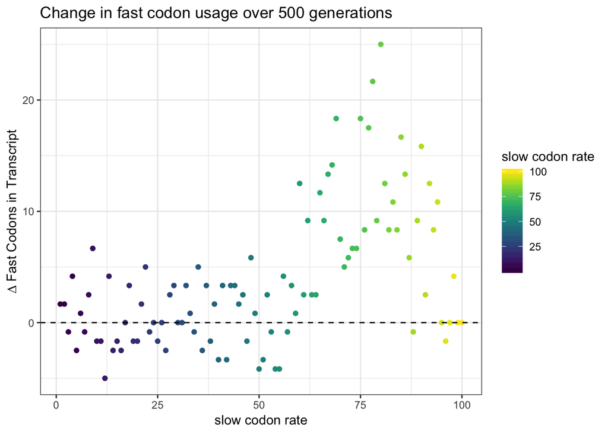

```r
transcript_stats2 <- transcript_stats %>% arrange(`Min Rate`, Generation,Pct_fast) %>% group_by(`Min Rate`) %>% mutate(codon_dif = last(Pct_fast)- Pct_fast)
transcript_stats_difference <- transcript_stats2 %>% filter(Generation == 0) %>% arrange(`Min Rate`)
difference_plot <- ggplot(transcript_stats_difference, aes(y = codon_dif, x = `Min Rate`, group = 1)) + geom_point(aes(colour = `Min Rate`)) + scale_color_viridis() + labs(title = 'Change in fast codon usage over 500 generations', x = 'slow codon rate',  y = '∆ Fast Codons in Transcript', color = 'slow codon rate' ) + geom_hline(yintercept=0, linetype="dashed", color = "black") + theme_bw()
difference_plot
```

```r
save_plot("change_in_fast_codon_usage_500_gen.png", difference_plot, base_aspect_ratio = 1.3)
#geom_smooth(method = 'lm', se = FALSE, fullrange = TRUE, color = '#2ca25f', size = 0.5) +
```

## Binning slow codon rates into percentiles and graphing

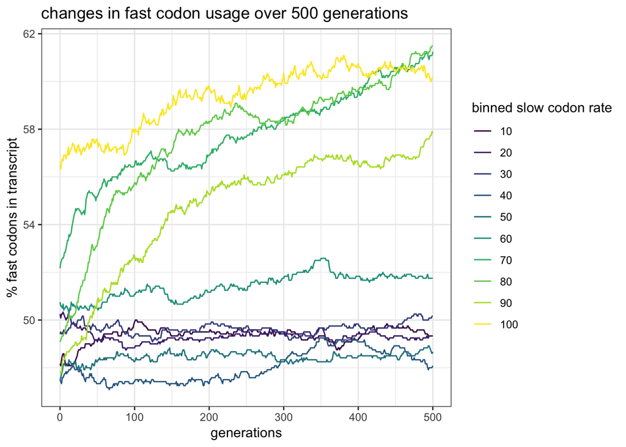

```r
transcript_stats_bin <- transcript_stats %>% mutate(percentile = cut(`Min Rate`,
                                       breaks = c(0,10,20,30,40,50,60,70,80,90,100),
                                       labels = c("10","20","30","40","50","60","70","80","90","100")))
transcript_stats_average <- transcript_stats_bin %>% group_by(Generation,percentile) %>% summarize(mean = mean(Pct_fast), sd= sd(Pct_fast))
percentile_plot <- ggplot(transcript_stats_average, aes(x = Generation, y= mean, group = percentile)) + geom_line(aes(color = percentile)) + scale_color_viridis_d() + labs(title = 'changes in fast codon usage over 500 generations', x = 'generations',  y = '% fast codons in transcript', color = 'binned slow codon rate' ) + theme_bw()
percentile_plot
```

```r
save_plot("change_in_fast_codon_usage_500_gen_lineplot.png", percentile_plot, base_aspect_ratio = 1.3)
```

```r
transcript_stats<- read.csv("data/presentation_datasets/transcript_stats_all_new.csv", header = TRUE)
head(transcript_stats)
```

|  | Generation | Population | Slow_Count | Fast_Count | Mut_Loc | Mutation | Prod_rt | Min |
| --- | --- | --- | --- | --- | --- | --- | --- | --- |
| 1 | 0 | popB | 57 | 63 | 61 | 1 | 1.404 | 1 |
| 2 | 1 | popB | 57 | 63 | 35 | 1 | 1.404 | 1 |
| 3 | 2 | popB | 56 | 64 | 47 | 100 | 1.682 | 1 |
| 4 | 3 | popB | 55 | 65 | 79 | 100 | 1.697 | 1 |
| 5 | 4 | popB | 54 | 66 | 26 | 100 | 1.754 | 1 |
| 6 | 5 | popB | 55 | 65 | 52 | 1 | 1.597 | 1 |

```r
transcript_stats_bin <- transcript_stats %>% mutate(percentile = cut(Min,
                                       breaks = c(0,10,20,30,40,50,60,70,80,90,100),
                                       labels = c("10","20","30","40","50","60","70","80","90","100")))
head(transcript_stats_bin)
```

|  | Generation | Population | Slow_Count | Fast_Count | Mut_Loc | Mutation | Prod_rt | Min | percentile |
| --- | --- | --- | --- | --- | --- | --- | --- | --- | --- |
| 1 | 0 | popB | 57 | 63 | 61 | 1 | 1.404 | 1 | 10 |
| 2 | 1 | popB | 57 | 63 | 35 | 1 | 1.404 | 1 | 10 |
| 3 | 2 | popB | 56 | 64 | 47 | 100 | 1.682 | 1 | 10 |
| 4 | 3 | popB | 55 | 65 | 79 | 100 | 1.697 | 1 | 10 |
| 5 | 4 | popB | 54 | 66 | 26 | 100 | 1.754 | 1 | 10 |
| 6 | 5 | popB | 55 | 65 | 52 | 1 | 1.597 | 1 | 10 |

```r
transcript_stats_average <- transcript_stats_bin %>% group_by(Generation,percentile) %>% summarize(mean = mean(Fast_Count), sd= sd(Fast_Count))
head(transcript_stats_average)
```

| Generation | percentile | mean | sd |
| --- | --- | --- | --- |
| 0 | 10 | 60.6 | 3.272783 |
| 0 | 20 | 59.8 | 3.425395 |
| 0 | 30 | 59.3 | 4.191261 |
| 0 | 40 | 61.6 | 4.765618 |
| 0 | 50 | 57.6 | 5.601587 |
| 0 | 60 | 60.1 | 6.806043 |

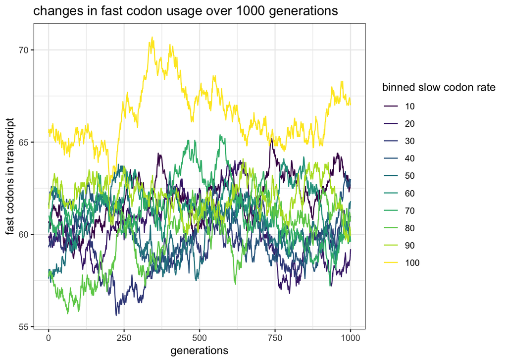

```r
percentile_plot <- ggplot(transcript_stats_average, aes(x = Generation, y= mean, group = percentile)) + geom_line(aes(color = percentile)) + scale_color_viridis_d() + labs(title = 'changes in fast codon usage over 1000 generations', x = 'generations',  y = 'fast codons in transcript', color = 'binned slow codon rate' ) + theme_bw()
percentile_plot
```

```r
save_plot("change_in_fast_codon_usage_1000_gen_lineplot.png", percentile_plot, base_aspect_ratio = 2.0)
```

Now to visualize the difference in fast codon usage from generation 1 to 1000

```r
transcript_stats2 <- transcript_stats %>% arrange(Min, Generation,Fast_Count) %>% group_by(Min) %>% mutate(codon_dif = last(Fast_Count)- Fast_Count)
head(transcript_stats2)
```

| Generation | Population | Slow_Count | Fast_Count | Mut_Loc | Mutation | Prod_rt | Min | codon_dif |
| --- | --- | --- | --- | --- | --- | --- | --- | --- |
| 0 | popB | 57 | 63 | 61 | 1 | 1.404 | 1 | 0 |
| 1 | popB | 57 | 63 | 35 | 1 | 1.404 | 1 | 0 |
| 2 | popB | 56 | 64 | 47 | 100 | 1.682 | 1 | -1 |
| 3 | popB | 55 | 65 | 79 | 100 | 1.697 | 1 | -2 |
| 4 | popB | 54 | 66 | 26 | 100 | 1.754 | 1 | -3 |
| 5 | popB | 55 | 65 | 52 | 1 | 1.597 | 1 | -2 |

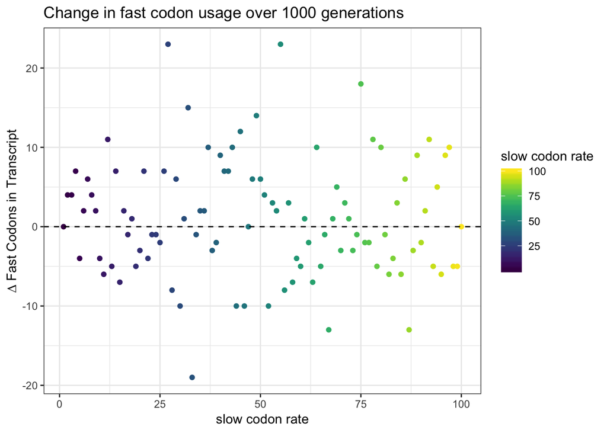

```r
transcript_stats_difference <- transcript_stats2 %>% filter(Generation == 0) %>% arrange(Min)
difference_plot <- ggplot(transcript_stats_difference, aes(y = codon_dif, x = Min, group = 1)) + geom_point(aes(colour = Min)) + scale_color_viridis() + labs(title = 'Change in fast codon usage over 1000 generations', x = 'slow codon rate',  y = '∆ Fast Codons in Transcript', color = 'slow codon rate' ) + geom_hline(yintercept=0, linetype="dashed", color = "black") + theme_bw()
difference_plot
```

```r
save_plot("change_in_fast_codon_usage.png", difference_plot, base_aspect_ratio = 1.3)
```

But, what about changes in protein production??

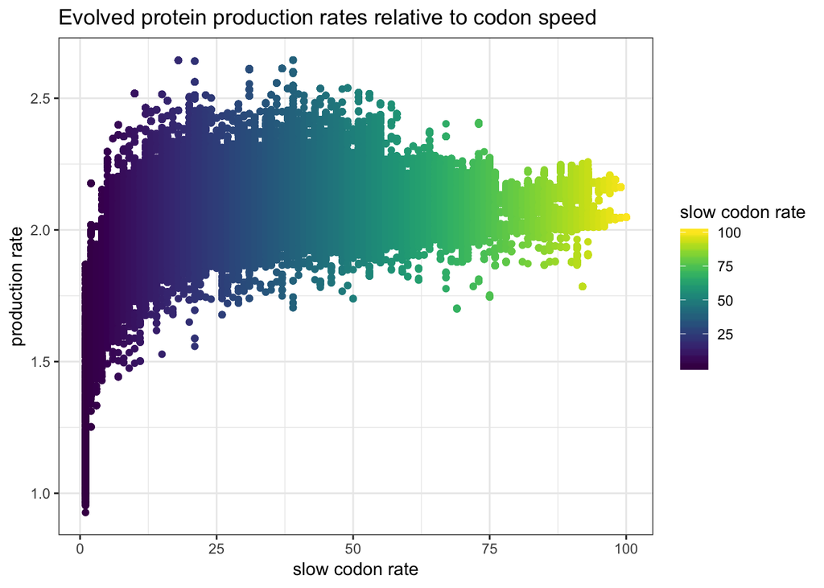

```r
evolved_rate_array <- read.csv("data/presentation_datasets/transcript_stats_all_new.csv", header = TRUE)
evolved_rate_df <- as.data.frame(evolved_rate_array)
evolved_rate_df <- arrange(evolved_rate_df, Min)
ratio_plot <- ggplot(evolved_rate_df, aes(x = Min, y= Prod_rt, group = 1)) + geom_point(aes(colour = Min)) + scale_color_viridis() + ylab('production rate') + xlab('slow codon rate') + theme(legend.position = 'none') +
  ggtitle('Evolved protein production rates relative to codon speed') +
  labs(color = 'slow codon rate') +
  theme_bw()
plot(ratio_plot)
```

```r
save_plot("array_evolved_production_rates.png", ratio_plot, base_aspect_ratio = 1.3)
```

```r
evolved_rate_array <- read.csv("data/presentation_datasets/final_fitness_1000_gen.csv", header = TRUE)
evolved_rate_df <- as.data.frame(evolved_rate_array)
head(evolved_rate_array)
```

|  | Min | Max | Rate |
| --- | --- | --- | --- |
| 1 | 100 | 100 | 2.048 |
| 2 | 10 | 100 | 1.966 |
| 3 | 1 | 100 | 1.753 |
| 4 | 11 | 100 | 1.872 |
| 5 | 12 | 100 | 2.037 |
| 6 | 13 | 100 | 1.870 |

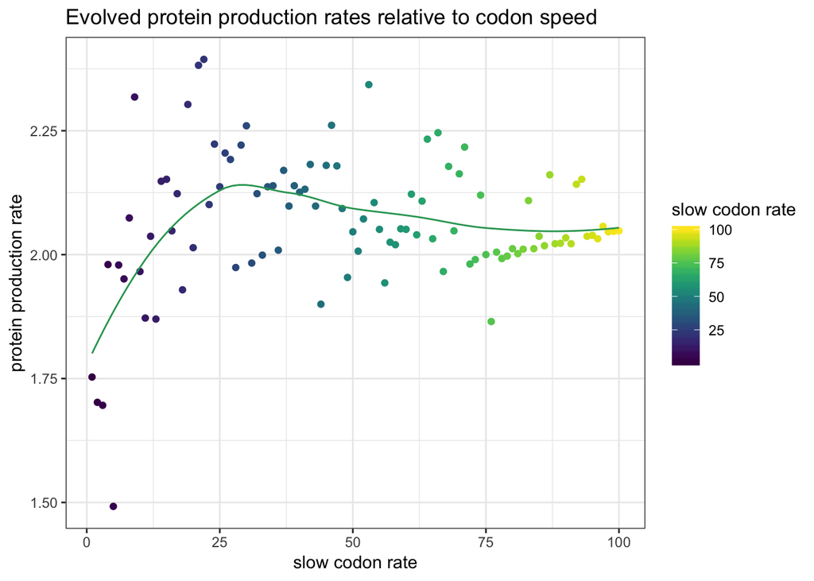

```r
ratio_plot <- ggplot(evolved_rate_df, aes(x = Min, y= Rate, group = 1)) + geom_point(aes(colour = Min)) + scale_color_viridis() + ylab('protein production rate') + xlab('slow codon rate') + theme(legend.position = 'none') +
  ggtitle('Evolved protein production rates relative to codon speed') +
  labs(color = 'slow codon rate') +
  theme_bw() + geom_smooth(method = 'loess', se = FALSE, fullrange = TRUE, color = '#2ca25f', size = 0.5)
plot(ratio_plot)
```

```r
save_plot("array_evolved_production_rates.png", ratio_plot, base_aspect_ratio = 1.3)
```